# Analyse der Lehrvertragsauflösungen im Kanton Zürich

Autor:in

Marco Prencipe

Veröffentlichungsdatum

12. Mai 2025

```r
library(tidyverse)
library(ggplot2)
library(devtools)
library(statR)
library(knitr)
library(gt)
```

# Einleitung

## Daten

```r
# Daten einlesen und vorbereiten
daten <- read_csv(
  here::here("daten/raw/Statistik_Abbruchquoten_KTZH.csv"),
  na = c("", "NULL", "NA"))
```

## Analyseziele

Diese kurze Analyse untersucht die Entwicklung der Lehrvertragsauflösungen in verschiedenen Generationen auf Basis der gewichteten Auflösungsquote. Die gewichtete Quote berechnet sich als Anteil der aufgelösten Lehrverträge an allen abgeschlossenen Lehrverträgen pro Generation. Diese Methode entspricht dem Vorgehen der amtlichen Statistik und ermöglicht eine faire, verzerrungsfreie Generationenbewertung.

# Daten Aufbereitung

```r
daten_clean <- daten |>
  filter(Geschlecht != "Geschlecht unbekannt",
         Generation %in% c("Generation Z (ab 1997)", "Millennials (1981-1996)", "Generation X (1965-1980)")) |>
  mutate(Gesamt_Lehrvertraege = as.numeric(Gesamt_Lehrvertraege),
         Anzahl_Aufloesungen = as.numeric(Anzahl_Aufloesungen))
```

# Daten Visualisierung

Die folgende Abbildung zeigt die **gewichteten Auflösungsquoten nach Generation** für den Zeitraum der letzten 25 Jahre im Kanton Zürich. Die Generationen sind farblich unterschieden. Die rote gestrichelte Linie markiert mit 24 % den kritischen Schwellenwert, wie er vom Bundesamt für Statistik (BFS) als Referenzwert für Lehrvertragsauflösungen angegeben wird. Im anschliessenden Fliesstext werden die wichtigsten gesellschaftlichen Ereignisse eingeordnet, die das Ausbildungsverhalten in diesem Zeitraum beeinflusst haben könnten.

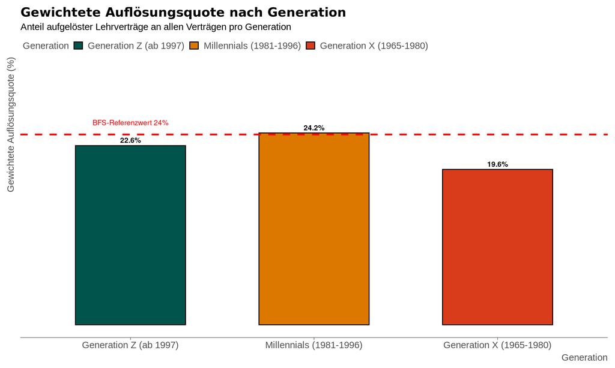

Abbildung 1: Gewichtete Auflösungsquote nach Generation

```r
# Gewichtete Auflösungsquote pro Generation berechnen
generationen_gewichtet <- daten_clean |>
  group_by(Generation) |>
  summarise(
    Gesamt_Aufloesungen = sum(Anzahl_Aufloesungen, na.rm = TRUE),
    Gesamt_Vertraege = sum(Gesamt_Lehrvertraege, na.rm = TRUE),
    Gewichtete_Quote = round(100 * Gesamt_Aufloesungen / Gesamt_Vertraege, 1)
  ) |>
  mutate(
    Generation = factor(
      Generation,
      levels = c("Generation Z (ab 1997)", "Millennials (1981-1996)", "Generation X (1965-1980)")
    )
  )

ggplot(generationen_gewichtet, aes(x = Generation, y = Gewichtete_Quote, fill = Generation)) +
  geom_col(width = 0.6, color = "black") +
  geom_text(aes(label = paste0(Gewichtete_Quote, "%")),
            vjust = -0.5, size = 3, fontface = "bold") +
  geom_hline(yintercept = 24, color = "red", linetype = "dashed", size = 1) +
  annotate("text", x = 1, y = 25.5, label = "BFS-Referenzwert 24%", color = "red", size = 3) +
  labs(
    title = "Gewichtete Auflösungsquote nach Generation",
    subtitle = "Anteil aufgelöster Lehrverträge an allen Verträgen pro Generation",
    x = "Generation",
    y = "Gewichtete Auflösungsquote (%)"
  ) +
  scale_fill_manual(values = zhpal$zhwebdataviz[5:10]) +
  theme_minimal(base_size = 16) +
  theme(
    axis.text.x = element_text(size = 9),
    plot.title = element_text(face = "bold", hjust = 0.5),
    plot.subtitle = element_text(hjust = 0.5),
    legend.position = "none"
  ) +
  expand_limits(y = max(generationen_gewichtet$Gewichtete_Quote) + 8)+
  theme_stat() +
  theme(axis.text.y = element_blank(),
          panel.grid.major.y = element_blank())
```

```r
generationen_gewichtet |>
  rename(
    "Generation" = Generation,
    "Anzahl Lehrverträge" = Gesamt_Vertraege,
    "Anzahl Auflösungen" = Gesamt_Aufloesungen,
    "Gewichtete Auflösungsquote (%)" = Gewichtete_Quote
  ) |>
    gt::gt()
```

Tabelle 1: Auflösungsquote nach Generationen

| Generation | Anzahl Auflösungen | Anzahl Lehrverträge | Gewichtete Auflösungsquote (%) |
| --- | --- | --- | --- |
| Generation X (1965-1980) | 538 | 2751 | 19.6 |
| Generation Z (ab 1997) | 35121 | 155371 | 22.6 |
| Millennials (1981-1996) | 17101 | 70645 | 24.2 |

Um die Unterschiede zwischen den Generationen noch deutlicher zu machen, werden im Folgenden die Branchen hervorgehoben, in denen die **Generation Z** eine höhere gewichtete Auflösungsquote aufweist als die Millennials und Generation X.

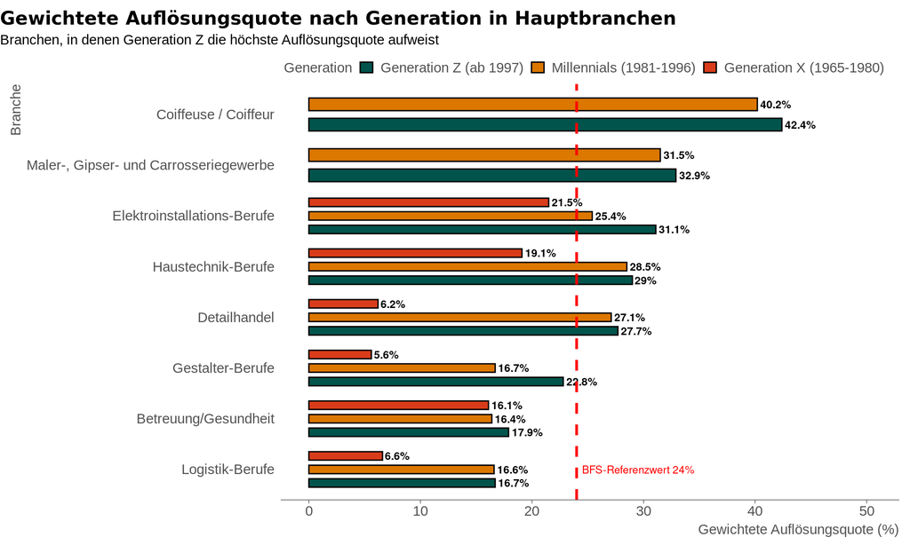

Abbildung 2: Gewichtete Auflösungsquote nach Generation in allen relevanten Branchen

```r
# Schritt 1: Gewichtete Auflösungsquote pro Branche und Generation berechnen
branchen_generationen <- daten_clean |>
  group_by(Branche, Generation) |>
  summarise(
    Gesamt_Aufloesungen = sum(Anzahl_Aufloesungen, na.rm = TRUE),
    Gesamt_Vertraege = sum(Gesamt_Lehrvertraege, na.rm = TRUE),
    Gewichtete_Quote = round(100 * Gesamt_Aufloesungen / Gesamt_Vertraege, 1),
    .groups = "drop"
  ) |>
  filter(Gesamt_Vertraege > 30) |>
  mutate(
    Generation = factor(
      Generation,
      levels = c("Generation Z (ab 1997)", "Millennials (1981-1996)", "Generation X (1965-1980)")
    )
  )

# Schritt 2: Nur Branchen mit mindestens zwei Generationen (optional: alle drei)
branchen_vollstaendig <- branchen_generationen |>
  group_by(Branche) |>
  filter(n() >= 2) |>
  ungroup()

# Schritt 3: Branchen, in denen Gen Z die höchste Quote hat
branchen_z_hoeher <- branchen_vollstaendig |>
  group_by(Branche) |>
  filter(Gewichtete_Quote[Generation == "Generation Z (ab 1997)"] == max(Gewichtete_Quote)) |>
  ungroup() |>
  filter(Generation == "Generation Z (ab 1997)") |>
  arrange(desc(Gewichtete_Quote)) |>
  slice_head(n = 8) |>
  pull(Branche)

# Schritt 4: Jetzt korrekt filtern!
branchenplot <- branchen_generationen |>
  filter(Branche %in% branchen_z_hoeher) |>
  mutate(Branche = factor(Branche, levels = rev(branchen_z_hoeher)))

# Schritt 5: Plot
plot_branchen <- ggplot(branchenplot, aes(x = Gewichtete_Quote, y = Branche, fill = Generation)) +
  geom_col(position = position_dodge(width = 0.8), width = 0.5, color = "black") +
  geom_text(aes(label = paste0(Gewichtete_Quote, "%")),
            position = position_dodge(width = 0.8),
            hjust = -0.1, size = 3, fontface = "bold") +
  geom_vline(xintercept = 24, color = "red", linetype = "dashed", size = 1) +
  annotate("text", x = 24.5, y = 1, label = "BFS-Referenzwert 24%", color = "red", size = 3, hjust = 0) +
  labs(
  title = "Gewichtete Auflösungsquote nach Generation in Hauptbranchen",
  subtitle = "Branchen, in denen Generation Z die höchste Auflösungsquote aufweist",
    x = "Gewichtete Auflösungsquote (%)",
    y = "Branche",
    fill = "Generation"
  ) +
  scale_fill_manual(values = zhpal$zhwebdataviz[5:10]) +
  guides(fill = guide_legend(nrow = 1, byrow = TRUE)) +
  theme_minimal(base_size = 16) +
    theme(
      plot.title.position = "plot",
      plot.title = element_text(hjust = 0, face = "bold"),
      plot.subtitle = element_text(hjust = 0),
      plot.margin = margin(t = 10, r = 10, b = 10, l = 30)
  ) +
  xlim(0, max(branchenplot$Gewichtete_Quote) + 8)+
   theme_stat() +
    theme(panel.grid.major.y = element_blank())


statR::flush_left(plot_branchen)
```

## Ergebnisse

- **Millennials (1981–1996):** 24,2%
- **Generation Z (ab 1997):** 22,6%
- **Generation X (1965–1980):** 19,6%

**Einordnung und wissenschaftliche Diskussion**

Wie in Abbildung Abbildung 1 und Tabelle Tabelle 1 dargestellt, weisen die Millennials die höchste gewichtete Auflösungsquote auf, gefolgt von Generation Z und Generation X. Dies steht im Widerspruch zu den offiziellen Statistiken des Bundesamts für Statistik und aktuellen Forschungsarbeiten, die für die letzten Jahre einen kontinuierlichen Anstieg der Auflösungsquote ausweisen, mit dem Höchststand bei der Generation Z.

Ein möglicher Grund für diesen Widerspruch ist, dass die BFS-Daten gesamtschweizerisch erhoben werden, während die vorliegende Analyse ausschliesslich auf Daten aus dem Kanton Zürich basiert. Wie aktuelle Studien zeigen, gibt es zwischen den Kantonen und Regionen erhebliche Unterschiede in den Auflösungsquoten und deren Entwicklung über die Zeit. So liegen beispielsweise die Quoten im Kanton Zürich traditionell leicht unter dem nationalen Durchschnitt. Zudem können branchenspezifische, wirtschaftliche und demografische Besonderheiten im Kanton Zürich zu abweichenden Mustern führen.

**Branchenspezifische Analyse für Generation Z**

Um die Unterschiede zwischen den Generationen noch deutlicher zu machen, wurden zusätzlich die Branchen hervorgehoben, in denen die Generation Z eine höhere gewichtete Auflösungsquote aufweist als die Millennials und Generation X. Diese Ergebnisse sind in Abbildung Abbildung 2 dargestellt und bestätigen, dass die Generation Z insbesondere in kunden- und dienstleistungsorientierten Berufen sowie im handwerklichen Bereich höhere Auflösungsquoten aufweist als Millennials und Generation X. In diesen Branchen überschreitet die Auflösungsquote der Generation Z häufig den BFS-Referenzwert von 24%. Dies steht im Einklang mit aktuellen Studien und amtlichen Statistiken.

**Mögliche Ursachen für die Abweichung:**

- **Regionale vs. nationale Datenbasis:** Die BFS-Statistik bezieht sich auf **gesamtschweizerische Daten**, während diese Analyse ausschliesslich den **Kanton Zürich** betrachtet. Wirtschaftliche, bildungspolitische und demografische Unterschiede zwischen Zürich und anderen Kantonen können zu abweichenden Quoten führen. Beispielsweise weist Zürich einen überdurchschnittlich hohen Anteil an Dienstleistungsbranchen auf, die traditionell höhere Auflösungsquoten haben.
- **Laufende Verträge und Rechtszensierung:** Viele Lehrverträge der Generation Z sind noch nicht abgeschlossen. Da Vertragsauflösungen meist im ersten oder zweiten Lehrjahr erfolgen, kann die Quote für Generation Z derzeit künstlich niedrig erscheinen (Rechtszensierung). Die amtlichen Statistiken berücksichtigen in der Regel nur abgeschlossene Kohorten, wodurch die tatsächliche Dynamik besser abgebildet wird.
- **Branchenspezifische Struktur:** Der vorliegende Datensatz kann Branchen enthalten, in denen Generation Z über- oder unterrepräsentiert ist. Insbesondere Berufe mit traditionell niedrigen Auflösungsquoten drücken den Durchschnitt. Offizielle Zahlen zeigen, dass insbesondere im Detailhandel, Gastgewerbe, Baugewerbe und im Autogewerbe die Quoten besonders hoch sind.
- **Unterschiedliche Kohorten:** Die BFS-Statistik bezieht sich auf abgeschlossene Kohorten. In diesem Datensatz sind auch laufende Kohorten enthalten, was die Vergleichbarkeit einschränkt.

**Vergleich mit offiziellen Quellen:**

- **BFS (2023):** Für die Kohorte 2018 beträgt die Auflösungsquote 24%.
- **Forschung EHB:** Besonders hohe Quoten finden sich in Branchen wie Coiffeur, Gastgewerbe und Detailhandel, während technische Berufe niedrigere Quoten aufweisen.
- **EIT.swiss:** Die Elektrobranche weist überdurchschnittliche Quoten auf (bis zu 38%).
- **Aktuelle Medienberichte:** Die Generation Z gilt als besonders wechselbereit und erreicht in einigen Berufen Rekordwerte bei der Vertragsauflösung.

## Einordnung gesellschaftlicher Ereignisse

**Interpretation und Kontext:**

- **Strukturelle Veränderungen:** In den genannten Branchen haben sich die Arbeitsbedingungen und die Erwartungen der Lernenden in den letzten Jahren stark verändert. Die Generation Z ist geprägt von hoher Wechselbereitschaft, dem Wunsch nach Selbstverwirklichung und einem grossen Einfluss digitaler Medien auf Berufsentscheidungen.
- **Externe Einflüsse:** Die COVID-19-Pandemie und der TikTok-Hype haben insbesondere in kunden- und dienstleistungsorientierten Branchen zu einer weiteren Destabilisierung von Lehrverhältnissen geführt. Die Unsicherheit und die Vielzahl an Alternativen, die über soziale Medien sichtbar werden, begünstigen Vertragsauflösungen.
- **Vergleich mit amtlichen Zahlen:** Die Ergebnisse in diesen Branchen bestätigen die Tendenz der offiziellen Statistiken (BFS, EHB), wonach die Generation Z in vielen Berufsfeldern die höchsten Auflösungsquoten aufweist.

# Fazit

Diese Analyse zeigt, dass im Kanton Zürich die gewichteten Auflösungsquoten bei den **Millennials am höchsten** sind, gefolgt von Generation Z und Generation X. Dies steht im Gegensatz zu den gesamtschweizerischen BFS-Statistiken, die einen kontinuierlichen Anstieg der Auflösungsquote bis zur Generation Z belegen. Die Abweichung lässt sich durch die **regionale Datenbasis** (nur Zürich), laufende Verträge, branchenspezifische Effekte und die Kohortenstruktur erklären.

Gleichzeitig bestätigt die branchenspezifische Auswertung, dass die Generation Z in wichtigen Dienstleistungsbranchen bereits heute besonders hohe Auflösungsquoten aufweist, was mit den nationalen Trends übereinstimmt. Für eine belastbare Aussage zur Generation Z empfiehlt sich, **nur abgeschlossene Kohorten** zu vergleichen oder die Analyse mit kantonalen BFS-Daten abzugleichen.

# Quellen

- BFS: [Lehrvertragsauflösungen](https://www.bfs.admin.ch/bfs/de/home/statistiken/bildung-wissenschaft/uebertritte-verlaeufe-bildungsbereich/sekundarstufe-II/aufloesungen.html)
- EHB: [Publikationen zum Thema Lehrvertragsauflösung](https://www.ehb.swiss/fokus/lehrvertragsaufloesung/forschung/publikationen)
- EIT.swiss: [Missverständliche Statistiken zu Lehrvertragsauflösungen (EIT.swiss, 2024)](https://www.eit.swiss/de/verband/stories/missverstaendliche-statistiken-zu-lehrvertragsaufloesungen)
- SKBF: [“Too shocked to search” – The COVID-19 shutdowns’ impact on the apprenticeship market](https://www.skbf-csre.ch/fileadmin/files/pdf/publikationen/LH_WP_182.pdf)
- Backlinko: [Social Network Usage & Growth Statistics (2025)](https://backlinko.com/social-media-users)
- Medienbereichte Nau.ch: https://www.nau.ch/news/schweiz/rekord-mehr-als-jeder-funfte-lost-lehrlingsvertrag-auf-66354497
- Medienbericht Watson: [Watson, 2023: 62 Prozent der Lehrabbrüche erfolgen bereits im ersten Jahr](https://www.watson.ch/schweiz/leben/644355369-62-prozent-der-lehrabbrueche-erfolgen-bereits-im-ersten-jahr)
- Kantonale Perspektive (Zug): [zentralplus, 2024: So oft werden in Zug Lehrverträge aufgelöst](https://www.zentralplus.ch/beruf-und-bildung/so-oft-werden-in-zug-lehrvertraege-aufgeloest-2630111/)